# 聚焦桃園 外籍移工之探討

遠離家鄉來到台灣的外籍移工，在這裡賺到人生的第一桶金，但在截然不同的環境下生存，遇到種種問題......

全球化脈絡下，國際移工的流動速度非常頻繁

#### 1980年代

國內勞力短缺，導致許多產業出走，引進外勞是維持台灣產業競爭力的方式之一，因此是否開放外勞，成為一個重要的議題

#### 1989年

因應國家建設開始聘用國際移工

#### 1992年

《就業服務法》通過，其中設有外籍勞工專章，允許民間產業引進外勞，並且陸續開放各產業聘僱外國人

至今開放25年，移工的人數已達67萬人，橫跨三級產業，不論是在農業中的船員或是在社福中的看護都可以看到移工的身影，移工儼然成為台灣不可或缺的勞動力。

### 台灣工業部門缺工嗎？

# 台灣工業部門缺工嗎？

移工與台灣就業者之間的人數差距不斷地縮短，2017年「台灣就業移工比」為17:1

[interactive chart not shown]

從缺工人數來看，工業部門主要缺工的行業分別為製造業、營造業，雖然引進外籍勞工，工業部門缺工的人數有在下降，但下降的幅度很有限，原因為二：  
1. 申請國際移工的配額有限，來保障國民的工作機會。  
2. 台灣勞動者不願從事3K（辛苦、汙穢、危險）產業，不僅環境髒亂、危害性化學物品種類等特性，可能會影響勞工安全與健康，所以大部分廠商都是聘用國際移工來工作。

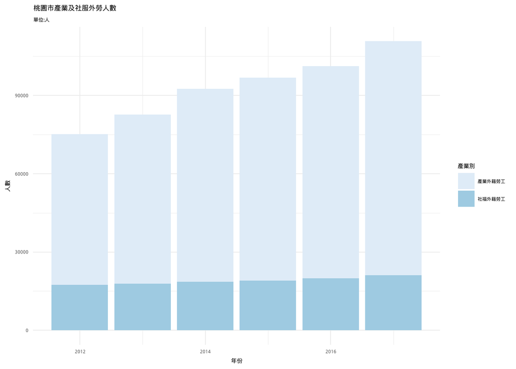

### 桃園市產業及社服外勞人數

桃園為何那麼多產業移工？主要原因為桃園是全臺第一工業科技大市，臺灣五百大製造業有超過三分之一在桃園設廠，工業產值常居全臺之冠，桃園擁有32個報編工業區，從傳統產業到高科技產業聚落。另外因應「3K行業專案」和2013年新增「外加就業安定費附加外勞數額」更間接的推動廠商多僱用移工。而桃園的外籍勞工主要從事的工作項目多為：三Ｋ行業專案、附加外籍勞工等的製造業產業

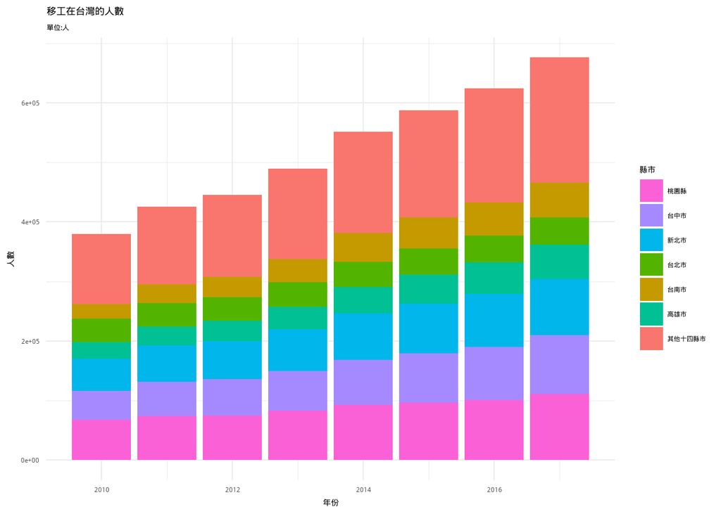

### 移工在台人數

【桃園移工對勞動需求的意義】 全台最多移工的地區，分別是桃園、台中、新北，從歷年的數據來看，桃園一直居於首位，將近1/6的移工選擇在桃園就業。細分桃園移工工作的產業類別大多為產業外籍勞工，只有少部分（1/5）的外籍勞工在社福產業工作。

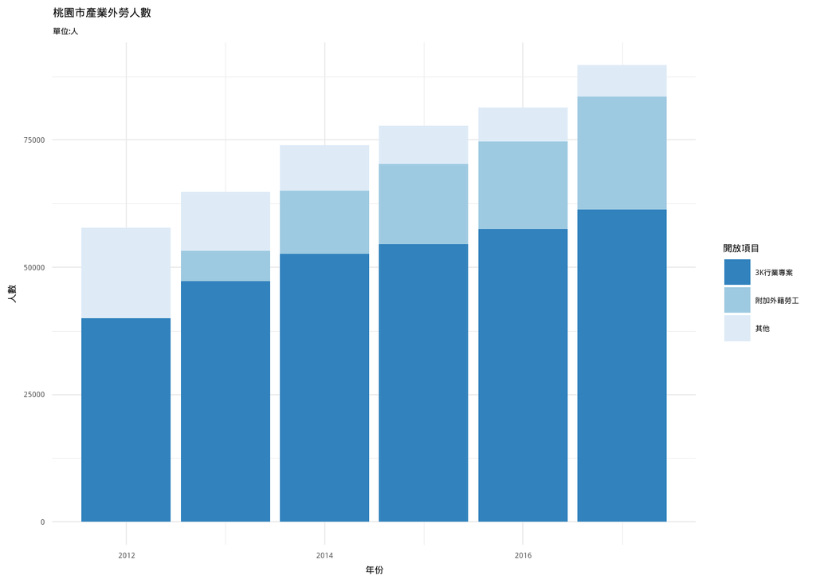

### 桃園市產業外勞人數

桃園為何那麼多產業移工？主要原因為桃園是全臺第一工業科技大市，臺灣五百大製造業有超過三分之一在桃園設廠，工業產值常居全臺之冠，桃園擁有32個報編工業區，從傳統產業到高科技產業聚落。另外因應「3K行業專案」和2013年新增「外加就業安定費附加外勞數額」更間接的推動廠商多僱用移工。而桃園的外籍勞工主要從事的工作項目多為：三Ｋ行業專案、附加外籍勞工等的製造業產業

### 由於跨國勞動體系複雜，當移工遭遇剝削與傷害時，輸出勞力母國與台灣，往往因爲法規的「灰色地帶」，無法協助移工所面臨的困難。 菲律賓移工身上有多處在玻璃廠工作所造成的傷痕，但受傷後他擔心一休養反而會引來雇主或仲介的「關心」，更害怕從此被扣上「不認真工作」的帽子而遭受解雇。(轉自：桃園市群眾服務協會)

# 桃園的隱形人口

桃園市是最多移工聚集之地，他們離鄉背井來到台灣，為的是有更好的生活而努力打拼，但當他們在工作中面臨歧視與剝削時，例如：被積欠薪資、被毆打辱罵、被性侵或者是職場傷害等等，他們卻會猶豫是否要向外求助？還是選擇吞忍？移工的困境不僅來自於語言和政策的不暸解，還有仲介制度的存在，使其面臨佣金、服務費負擔過高。且當移工遭受不平等對待或想要轉換雇主時，往往會受到雇主與仲介的雙重壓力，更甚逼迫移工「自願」離職回國，如此一來企業的移工配額就不會被影響、可以馬上再請一個新的移工。

雖然桃園市政府積極的改善移工的生活環境，規劃公共空間，給予數量龐大的桃園移工群體於假日時可以休息聚會的地方，並首創「移工參與式預算」，推出移工休閒育樂參與式預算計畫，藉此辦理各種活動，期待移工對桃園更有認同感。另外，還設置「24小時外勞諮詢專線電話：1995」諮詢服務中心，陸續聘請菲、印、越、泰四國雙語人員，協助處理案件，解答相關法令疑義與弭平勞資爭議。但卻因為能溝通的窗口有限，且服務端的繁複行政流程，導致無法即時給予實際的幫助，更多的救助還是源自於非營利組織的幫忙與爭取，提供法律諮詢，緊急庇護、中文學習等等，來促進移工與本地社群多元文化交流並推動移工人權活動。

目前桃園還是有許多藍領移工的工作權及安心生活的權利正受迫害，例如：移工住宿、工作環境是否符合安全機制、仲介費是否抽取過高或者服務費費用過高等等，都是桃園市政府需要去落實與改善，不僅是在法案的制定及實地稽查的落實性，還有求助的管道是否簡化且又效率地實行，這樣才能更維護移工的權利。

### 人的氣質，決定了個人的人緣；城市的氣質，影響了城市的人氣。《移動的城市》

# 全球化下，人力的流動成為常態，人們跨越城鄉甚至國界以獲取更好的生活，無論是中國的北漂、到鄰近國家當「台幹」的青年，或者在政府廉價勞動力輸出政策驅使下大批離鄉打拼的東南亞移工，其本質上並沒有什麼不同，大家都是為了生活而選擇的結果。

# 至今20餘年的開放，移工的角色不僅僅是勞動市場的潤滑劑，而是桃園文化的一環，仔細一看，可以發現火車站的周圍開起了異國的餐廳與小商店，來來往往的說著自己國家的母語。這裡是移工假日的休閒地，也是文化建立與暸解的起源，乘載了許多移工的夢想，同時也成為移工認同的地方，更甚成為台灣的一份子，移工改變了桃園的樣貌，也帶動桃園的經濟，不論是在消費上，還是外籍移工親友來探親，都會促進桃園的經濟與觀光產業。桃園是「異鄉人·台灣夢」的縮影，是最平凡卻也是重要的一部分，我們重塑的想法不只單單在桃園，而是台灣人對於生活周遭的看法與了解，並創造一個和解與包容的空間。

## 衝鋒特戰隊

[figure not shown]

陳宜榛 經濟所, 碩一

[figure not shown]

周緬緬 經濟所, 碩一

[figure not shown]

郭家瑄 經濟所, 碩一